# Project 1

Jakob Martinussen and Marte Saghagen

September 6, 2017

# Part 1: Explanatory analysis of the dataset

```r
data(SLID, package = "car")
SLID <- SLID[complete.cases(SLID), ]
g <- ggpairs(SLID)
```

## Assumptions of multiple linear regression (MLR) analysis

If we want to perform MLR analysis, the following must hold true:

1. Wages must be a linear response to the covariates, education, age, sex and language, i.e. $\bf Y = \bf X\bf \beta + \bf \varepsilon$.
2. The error needs to have equal and uncorrelated variance for each covariate, i.e. $\text{Var}(\varepsilon) = \sigma^2 I$.
3. Errors need to be additive (see formula related to pt. 1).
4. Errors need to be normally distributed, i.e. $\varepsilon \sim N_n(0, \sigma^2 I)$.

# Part 2: Linear regression with mylm package

In this project we have created our own R-package, named `mylm`, to handle linear models for Gaussian data. We will use this package in order to analyze an example dataset, which consists of $n = 3987$ observations of the following 5 variables:

| `wages` - Composite hourly wage rate from all jobs. |
| --- |
| `education` - Number of years in schooling. |
| `age` - Of individual in years. |
| `sex` - ‘Male’ or ‘Female’. |
| `language` - ‘English’, ‘French’ or ‘Other’. |

We want to study how the qualitative variable `wages` depends on one or more explanatory variables. The `mylm` package consists of the following functions:

| `print.mylm` - Invokes the `mylm` function and prints the result, including the estimated regression coefficients. |
| --- |
| `plot.mylm` - Draws a scatter plot with fitted values and residuals. |
| `summary.mylm` - Returns a list of summary statistics of the fitted linear model, e.g. coefficients, standard errors, tests of significance, and so on. |
| `anova.mylm` - Gives the results of a sequential ANOVA. |

### Notation:

- ${\bf Y}: (n \times 1)$ vector of responses.
- ${\bf X}: (n \times p)$ design matrix.
- ${\bf \beta}: (p \times 1)$ vector of regression parameters including the intercept ($p = k + 1$).
- ${\bf \varepsilon}: (n \times 1)$ vector of random errors.

We will now create a linear regression model using the `mylm` package, and present the results. We will also present the linear regression formulas used in order to make the functions in the `mylm` package.

## a)

This function invokes the `$call` method of the mylm object, and prints the result in addition to the resulting regression coefficients.

### Estimates of the regression coefficients

Estimates of the regression coefficients $\hat \beta$ are calculated with the least squares (LS) and most likelihood (ML) estimator
$$\hat \beta = ({\bf X}^T {\bf X})^{-1} {\bf X}^T {\bf Y}.$$

An example of how to use `mylm` in order to calculate estimated correlation coefficients follows

```r
library(mylm)
model1 <- mylm(wages ~ education, data = SLID)
print(model1)
```

```
## Call:
## mylm(formula = wages ~ education, data = SLID)
##
## Coefficients:
##      (Intercept) education
## [1,]    4.971691 0.7923091
```

## b)

The estimates of the intercept and regression coefficients is presented in Part 2 a)

### $\sigma^2$, covariance matrix and standard errors of the parameter estimates

In order to find the covariance matrix and standard errors we need the estimate for $\sigma^2$. It is found by the restricted maximum likelihood estimator
$$\hat{\sigma}^2 = \frac{\text{SSE}}{n - p},$$
where $\hat{\sigma}$ is the residual standard error. The residual sum of squares, SSE, is presented in Part 2 d).

From this, the estimated covariance matrix of the coefficients can be calculated by $\text{Cov}(\hat\beta)=\hat{\sigma}^2 ({\bf X}^T {\bf X})^{-1}$. The estimate of the covariance matrix for `model1` is

```r
model1$covmatrix
```

```
##             (Intercept)    education
## (Intercept)  0.28546972 -0.020348618
## education   -0.02034862  0.001525722
```

The standard errors of the intercept and regression coefficients are found by taking the square root of the covariance matrix, or ${\sqrt{c_{jj}}\hat{\sigma}}$, where $c_{jj}$ is diagonal element $j$ of $({\bf X}^T{\bf X})^{-1}$. For `model1` this gives the following

```r
model1$std_error_coeff
```

```
## (Intercept)   education
##  0.53429366  0.03906049
```

### Significance of the regression coefficients

We perform a $z$-test to test the significance of the estimated coefficients. The $z$-values for each coefficient $\hat{\beta_j}$ is calculated by
$$z_{\text{value}} = \frac{\hat{\beta_j}}{\sqrt{c_{jj}} \hat{\sigma}}$$

The result from the z-test on `model1` is

```r
model1$z_stat
```

```
##                  [,1]
## (Intercept)  9.305166
## education   20.284158
```

```r
model1$pvalue_z
```

```
##                     [,1]
## (Intercept) 1.337833e-20
## education   1.774739e-91
```

### Interpretation of the parameter estimates

The parameter estimates represent the mean estimated change in the response caused by one unit of change in the respective predictor variable while holding other predictors in the model constant. The estimated coefficient for `education` is 0.7923091. The coefficient indicates that for every additional unit in `education`, we can expect `wages` to increase by an average of 0.7923091.

## c)

This function draws a scatter plot with *fitted* values on the $x$-axis, and residuals on the $y$-axis, by utilizing the `ggplot` functionality from the `ggplot2` library. It is also used to plot the *observed* values against the residuals.

### Fitted values and residuals

The fitted values and residuals are calculated by the following formulas,

$$\hat{\bf Y} = {\bf X} \hat{\beta}$$
$$\hat{\varepsilon}={\bf Y} - \hat{\bf Y},$$

and can be drawn in a scatter plot, as explained, above in the following way

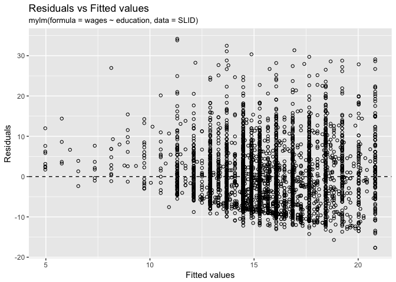

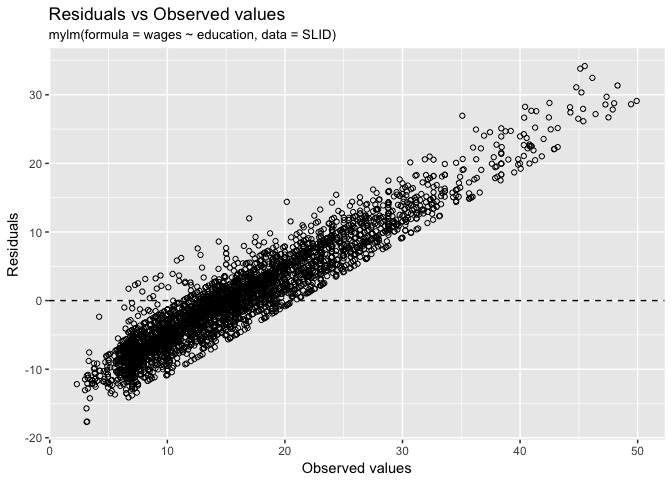

```r
plot(model1)
```

## d)

### SSE, SST and degrees of freedom

The expressions for the residual sum of squares ($\text{SSE}$) and the sums of squares total ($\text{SST}$) are
$$\text{SSE} = \hat{\varepsilon}^T \hat{\varepsilon}$$
$$\text{SST} = {\bf Y}^T ({\bf I} - \frac{1}{n} {\bf 1 1}^T){\bf Y}$$

The calculated values for $\text{SSE}$ and $\text{SST}$ for `model1` is

```r
model1$SSE
```

```
##          [,1]
## [1,] 223694.3
```

```r
model1$SST
```

```
##          [,1]
## [1,] 246790.5
```

The degrees of freedom for a linear model is $n - p$. For this particular model we therefore have 3987 $-$ 2 $=$ 3985 degrees of freedom.

### Significance of the regression

We test the significance of the regression using a $\chi^2$-test with $k = p - 1$ degrees of freedom. We test if at least one of the regression parameters is different from 0. The expression for the $\chi^2$-statistics is
$$\chi_k^2 = \frac{\text{SST} - \text{SSE}} {\frac{\text{SSE}}{n - p}}.$$
The critical values for the tests are

```r
model1$critical_z
```

```
## [1] -1.959964  1.959964
```

```r
model1$critical_chi
```

```
## [1] 0.0009820691 5.0238861873
```

The $z$-test is a single hypothesis test where we are interested in testing one null hypothesis against an alternative hypothesis. We test if a regression parameter $\beta_j$ is significant: $H_0: \beta_j = 0 \text{ vs. } H_1: \beta_j \neq 0$. Here we assume that all other regression parameters are *not* equal to zero.

This means we test if at least one of the regression coefficients is different from 0.

### ANOVA

In the ANOVA function, the $\chi^2$-test is calculated as when the testing linear hypotheses, but with some alterations. Instead of comparing the full regression model to a smaller model, we are now looking at the change in SSE between two smaller models.

Let $A$ be the full regression model and $B1$ and $B2$ be two smaller models, for example $B1$ with only intercept and $B2$ with intercept *and* education. Then the test statistics is:
$$\chi_\text{dfB1-dfB2}^2=\frac{\text{SSE}_{B1}-\text{SSE}_{B2}}{\frac{\text{SSE}_A}{\text{df}_A}}$$
The complete output of the function `anova` with `model1`

```r
anova(model1)
```

[output not shown]

## e)

The coefficient of determination, $R^2$ is estimated with the formula $R^2 = 1-SSE/SST$. $R^2$ for this model is 0.0935863. $R^2$ can take a value between 0 and 1 and closer it is to 1, the better the fit to the data.

## f)

The Pearson’s linear correlation coefficient is a measure of the linear correlation between two variables $x_i$ and $x_j$. It has a value between +1 and −1, where 1 is total positive linear correlation, 0 is no linear correlation, and −1 is total negative linear correlation. The expression is
$$r = \frac{\text{cov}(x_i,x_j)}{\sigma_{x_i}\sigma_{x_j}}$$
The numerical values for `model1` is

```r
model1$linear_corr_coeff
```

```
## [1] 1
```

### Output of `summary`

The complete output of the function `summary` with `model1`

```r
summary(model1)
```

```
## Call
## mylm(formula = wages ~ education, data = SLID)
##
## Residuals:
##         Min    1Q Median   3Q   Max
## [1,] -17.69 -5.82  -1.04 4.15 34.19
##
## Coefficients:
##             Estimate Std. Error z value     Pr(>|z|)
## (Intercept)   4.9717     0.5343    9.31 1.337833e-20 ***
## education     0.7923     0.0391   20.28 1.774739e-91 ***
##
## Signif. codes: 0 ´***´ 0.001 ´**´ 0.01 ´*´ 0.05 ´.´ 0.1 ´ ´ 1
##
## Residual standard error:  7.492267 on 3985 degrees of freedom
## Multiple R-squared:  0.09358627
## Chisquared-statistics:  411.4471 on 1 and 3985 DF,    p-value:  1.774739e-91
```

# Part 3: Multiple linear regression

## a)

We fit a linear regression model to the data with `wages` as the response with `education` and `age` as predictors.

```r
model2 <- mylm(wages ~ education + age, data = SLID)
```

## b)

```r
summary(model2)
```

```
## Call
## mylm(formula = wages ~ education + age, data = SLID)
##
## Residuals:
##        Min   1Q Median   3Q   Max
## [1,] -24.3 -4.5  -0.81 3.67 37.63
##
## Coefficients:
##             Estimate Std. Error z value      Pr(>|z|)
## (Intercept)  -6.0217     0.6189   -9.73  2.262949e-22 ***
## education     0.9015     0.0358   25.21 3.203056e-140 ***
## age           0.2571     0.0090   28.72 2.076930e-181 ***
##
## Signif. codes: 0 ´***´ 0.001 ´**´ 0.01 ´*´ 0.05 ´.´ 0.1 ´ ´ 1
##
## Residual standard error:  6.820314 on 3984 degrees of freedom
## Multiple R-squared:  0.2490697
## Chisquared-statistics:  1321.419 on 2 and 3984 DF,    p-value:  1.141507e-287
```

The estimates and standard errors of the intercepts and regression coefficients for `model2` is presented in the summary above. From the $z$-test we can see that all the regression parameters is significant in the model.

## c)

We fit two simple linear regression with only age and only education to compare with `model2`. The estimates of the coefficients for the two models are presented below.

```r
model2onlyage <- mylm(wages ~ age, data = SLID)
model2onlyage$coefficients
```

```
##                  [,1]
## (Intercept) 6.8909006
## age         0.2331079
```

```r
model1$coefficients
```

```
##                  [,1]
## (Intercept) 4.9716912
## education   0.7923091
```

# Part 4: Analysis of variance (ANOVA)

## a)

We fit a linear regression model to the data with `wages` as the response with `sex` and `language` as covariates. `model3a` is using dummy variable coding and `model3b` is using effect coding.

```r
model3a <- mylm(wages ~ sex + language, data = SLID)
summary(model3a)
```

```
## Call
## mylm(formula = wages ~ sex + language, data = SLID)
##
## Residuals:
##        Min    1Q Median   3Q   Max
## [1,] -14.5 -5.98  -1.32 4.17 36.12
##
## Coefficients:
##                Estimate Std. Error z value     Pr(>|z|)
## (Intercept)     13.8048     0.1810   76.26 0.000000e+00 ***
## sexMale          3.3985     0.2435   13.96 2.782976e-44 ***
## languageFrench  -0.1488     0.4963   -0.30 7.642642e-01
## languageOther    0.4180     0.3745    1.12 2.642991e-01
##
## Signif. codes: 0 ´***´ 0.001 ´**´ 0.01 ´*´ 0.05 ´.´ 0.1 ´ ´ 1
##
## Residual standard error:  7.684698 on 3983 degrees of freedom
## Multiple R-squared:  0.04690658
## Chisquared-statistics:  196.0237 on 3 and 3983 DF,    p-value:  3.049905e-42
```

Here we have performed a dummy variable coding of the categorical covariates, where `female` has become the reference category for `sex` and `english` has become the reference category for `language`. This is due to the alphabetical ordering of the categories.

This means that being an english-speaking woman is counted as being part of the average of the intercept, loosely speaking. As an example, a male is expected to have 3.3985456 more units of wage compared to a female.

```r
model3b <- mylm(wages ~ sex + language, data = SLID, contrasts = list(language = "contr.sum",
    sex = "contr.sum"))
summary(model3b)
```

```
## Call
## mylm(formula = wages ~ sex + language, data = SLID, contrasts = list(language = "contr.sum",
##     sex = "contr.sum"))
##
## Residuals:
##        Min    1Q Median   3Q   Max
## [1,] -14.5 -5.98  -1.32 4.17 36.12
##
## Coefficients:
##             Estimate Std. Error z value     Pr(>|z|)
## (Intercept)  15.5938     0.2023   77.09 0.000000e+00 ***
## sex1         -1.6993     0.1217  -13.96 2.782976e-44 ***
## language1    -0.0897     0.2168   -0.41 6.789603e-01
## language2    -0.2386     0.3420   -0.70 4.854827e-01
##
## Signif. codes: 0 ´***´ 0.001 ´**´ 0.01 ´*´ 0.05 ´.´ 0.1 ´ ´ 1
##
## Residual standard error:  7.684698 on 3983 degrees of freedom
## Multiple R-squared:  0.04690658
## Chisquared-statistics:  196.0237 on 3 and 3983 DF,    p-value:  3.049905e-42
```

Here we have performed an effect coding of the categorical covariates. This mean that the sum of the effects for the levels of the factor sums to zero. You can find the “missing” coefficient of the reference category by negating the sum of the other coefficients (related to the same covariate). Compared to the dummy variable coding, there is no real case where only the intercept is used.

In this coding scheme, `male` and `otherLanguage` are the “missing” categories. As an example, the missing coefficient for `otherLanguage` can be calculated by -(-0.0897211 + -0.2385605) = 0.3282816.

We can see how the design matrix changes between the two different coding schemes by selecting a 3 rows which represent all three languages. First the dummy variable coding:

```r
samples <- c(1, 164, 178)
model3a$X[samples, ]
```

```
##     (Intercept) sexMale languageFrench languageOther
## 1             1       1              0             0
## 322           1       0              1             0
## 348           1       0              0             1
```

And then the effect coding:

```r
model3b$X[samples, ]
```

```
##     (Intercept) sex1 language1 language2
## 1             1   -1         1         0
## 322           1    1         0         1
## 348           1    1        -1        -1
```

Here we clearly see that the levels sum to zero.

## b)

```r
anova(model3a)
```

```
## Analysis of Variance Table
## Response: wages
##          Df Sum sq X2 value      Pr(>X2)
## sex       1  11493   194.64 3.091762e-44 ***
## language  2     84     1.42 4.927909e-01
## Residuals  3983 235214.4 59
```

```r
anova(model3b)
```

```
## Analysis of Variance Table
## Response: wages
##          Df Sum sq X2 value      Pr(>X2)
## sex       1  11493   194.64 3.091762e-44 ***
## language  2     84     1.42 4.927909e-01
## Residuals  3983 235214.4 59
```

Sequential ANOVA of the two models `model3a` and `model3b` give the same result. `Sex` is significant when it is the only covariate in the model. `Language` is not significant when added to the model with `intercept` and `sex`.

```r
anova(mylm(wages ~ sex + language, data = SLID))
and
anova(mylm(wages ~ language + sex, data = SLID))
```

The commands above give different results because the terms are added sequentially. The commands produce a sequential table of the reductions in residual sum of squares (SSE) as each term in the regression formula is added in turn. Therefore the reductions in SSE will differ as the terms are added in different orders.

## c)

```r
model4a <- mylm(wages ~ sex + age + sex * age, data = SLID)
model4b <- mylm(wages ~ sex + age + sex * age, data = SLID, contrasts = list(language = "contr.sum",
    sex = "contr.sum"))
```

In `model4a` and `model4b` we have added an interaction term to the model where the two predictor variables are multiplied. The presence of a non-zero interaction indicates that the effect of one predictor variable on the response is different at different values of the other predictor variable.

```r
model4a$coefficients
```

```
##                   [,1]
## (Intercept)  7.7492628
## sexMale     -1.5729205
## age          0.1651027
## sexMale:age  0.1318890
```

If the interaction effect is non-zero, the interpretation of the coefficients changes. Let us explain this table further.

- In the case of `sexFemale`, we expect a base rate of 7.7492628 units of wage plus 0.1651027 for each additional year of age.
- For the case of `sexMale` we have a reduction of the base rate equal to -1.5729205, but this is *more* than compensated for by the additional increase in pay for each year of age, 0.131889.

```r
model4b$coefficients
```

```
##                    [,1]
## (Intercept)  6.96280254
## sex1         0.78646026
## age          0.23104718
## sex1:age    -0.06594448
```

- A male is expected to have a base rate of wage equal to 6.9628025 + (-1) $*$ 0.7864603 plus a wage increase for each additional year of age equal to 0.2310472 + (-1) $*$ -0.0659445.
- A female is expected to have a base rate of wage equal to 6.9628025 + 1 $*$ 0.7864603 plus a wage increase for each additional year of age equal to 0.2310472 + 1 $*$ -0.0659445.

In other words, men are expected to have a greater benefit of getting older when it comes to wage, compared to women.

Now we test whether the regression coefficients have a common slope or not, using a plot.

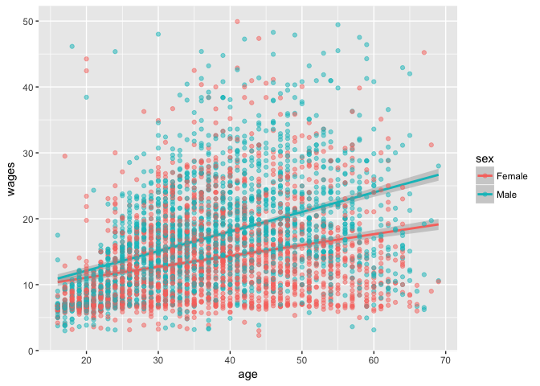

```r
ggplot(data = SLID) + aes(x = age, y = wages, col = sex) + geom_smooth(method = "lm",
    se = TRUE) + geom_point(alpha = 0.5)
```

```r
summary(model4a)
```

```
## Call
## mylm(formula = wages ~ sex + age + sex * age, data = SLID)
##
## Residuals:
##         Min    1Q Median   3Q  Max
## [1,] -20.87 -4.65  -1.43 3.58 35.4
##
## Coefficients:
##             Estimate Std. Error z value     Pr(>|z|)
## (Intercept)   7.7493     0.5109   15.17 5.644838e-52 ***
## sexMale      -1.5729     0.7244   -2.17 2.990533e-02   *
## age           0.1651     0.0131   12.56 3.479901e-36 ***
## sexMale:age   0.1319     0.0186    7.11 1.189903e-12 ***
##
## Signif. codes: 0 ´***´ 0.001 ´**´ 0.01 ´*´ 0.05 ´.´ 0.1 ´ ´ 1
##
## Residual standard error:  7.109952 on 3983 degrees of freedom
## Multiple R-squared:  0.1841407
## Chisquared-statistics:  898.9691 on 3 and 3983 DF,    p-value:  1.481239e-194
```

We see a non-zero interaction effect between `sexMale` and `age`, with a significance level stronger than $0.01$. The visual plot and the numeric analysis gives therefore the same conclusion.

# Part 5: Testing the `mylm` package

```r
education2 = SLID$education^2  #square of education
model5a <- mylm(wages ~ sex + age + language + education2, data = SLID)
model5b <- mylm(wages ~ language + age + language * age, data = SLID)
model5c <- mylm(wages ~ education - 1, data = SLID)
```

```r
summary(model5a)
```

```
## Call
## mylm(formula = wages ~ sex + age + language + education2, data = SLID)
##
## Residuals:
##         Min    1Q Median   3Q   Max
## [1,] -27.17 -4.28  -0.76 3.22 35.93
##
## Coefficients:
##                Estimate Std. Error z value      Pr(>|z|)
## (Intercept)     -1.8755     0.4403   -4.26  2.051321e-05 ***
## sexMale          3.4087     0.2084   16.35  4.008036e-60 ***
## age              0.2486     0.0087   28.70 3.719546e-181 ***
## languageFrench  -0.0755     0.4251   -0.18  8.589856e-01
## languageOther   -0.1345     0.3232   -0.42  6.771638e-01
## education2       0.0348     0.0013   26.99 1.901746e-160 ***
##
## Signif. codes: 0 ´***´ 0.001 ´**´ 0.01 ´*´ 0.05 ´.´ 0.1 ´ ´ 1
##
## Residual standard error:  6.576994 on 3981 degrees of freedom
## Multiple R-squared:  0.3022198
## Chisquared-statistics:  1724.235 on 5 and 3981 DF,    p-value:  0
```

From the summary we see that `sexMale`, `age` and `education2` are significant in the model. Increase in `age` and `education` results in a higher expected level of `wage`. The same goes for being male instead of female.

$R^2=$ 0.3022198, so the model only explains 30% of the variability in the data. A possible improvement to the model would be to exclude `language` from the fitted variables.

```r
summary(model5b)
```

```
## Call
## mylm(formula = wages ~ language + age + language * age, data = SLID)
##
## Residuals:
##         Min    1Q Median   3Q   Max
## [1,] -16.75 -4.83  -1.41 3.94 35.19
##
## Coefficients:
##                    Estimate Std. Error z value      Pr(>|z|)
## (Intercept)          6.5558     0.4107   15.96  2.304487e-57 ***
## languageFrench       2.8606     1.5961    1.79  7.308638e-02   .
## languageOther        0.8486     1.2352    0.69  4.920565e-01
## age                  0.2449     0.0107   22.91 3.689135e-116 ***
## languageFrench:age  -0.0839     0.0405   -2.07  3.802948e-02   *
## languageOther:age   -0.0370     0.0293   -1.26  2.071149e-01
##
## Signif. codes: 0 ´***´ 0.001 ´**´ 0.01 ´*´ 0.05 ´.´ 0.1 ´ ´ 1
##
## Residual standard error:  7.338975 on 3981 degrees of freedom
## Multiple R-squared:  0.1311705
## Chisquared-statistics:  601.0265 on 5 and 3981 DF,    p-value:  1.213615e-127
```

This model seems to have less explaining power than the previous one, as $R^2=$ 0.1311705. The only covariate significant at a 0.001 level is `age`. The other semi-significant effect is the interaction between `languageFrench` and `age`. We can therefore say with some amount of certainty that french speaking people are expected to less degree of wage increase related to increased age.

We are satisfied with fitting `language` as part of the model, especially when we compensate for the interaction effects. A possible improvement to the model is to add `education` as one of the fitted covariates.

```r
anova(model5b)
```

```
## Analysis of Variance Table
## Response: wages
##              Df Sum sq X2 value       Pr(>X2)
## language      2     70     1.29  5.247679e-01
## age           1  32009   593.78 3.771739e-131 ***
## language:age  2    293     5.44  6.596733e-02   .
## Residuals  3981 214418.9 54
```

The analysis of variance confirms that the interaction effect is the most crucial part of fitting `language` as a covariate. Still, the interaction effect has a relatively small explaining power relative to `age`.

```r
summary(model5c)
```

```
## Call
## mylm(formula = wages ~ education - 1, data = SLID)
##
## Residuals:
##        Min    1Q Median   3Q   Max
## [1,] -19.8 -5.34  -0.66 4.46 36.33
##
## Coefficients:
##           Estimate Std. Error z value Pr(>|z|)
## education   1.1467     0.0088  130.79        0 ***
##
## Signif. codes: 0 ´***´ 0.001 ´**´ 0.01 ´*´ 0.05 ´.´ 0.1 ´ ´ 1
##
## Residual standard error:  7.572276 on 3986 degrees of freedom
## Multiple R-squared:  0.07389171
## Chisquared-statistics:  318.0323 on 0 and 3986 DF,    p-value:  0
```

We can say with great certainty that `education` has a positive effect on `wage`. This is based on the value of the z-test, 130.7939856, resulting in p-value indistinguishable from 0.

There is no reason to believe that people without any education have zero wages. The result is that the coefficient for `education` becomes greater than it really is, in order to compensate for the missing intercept. A possible improvement is to include an intercept in the model.